# Credit Card Users Churn Prediction

### Question 6: What are the attributes that have a strong correlation with each other?

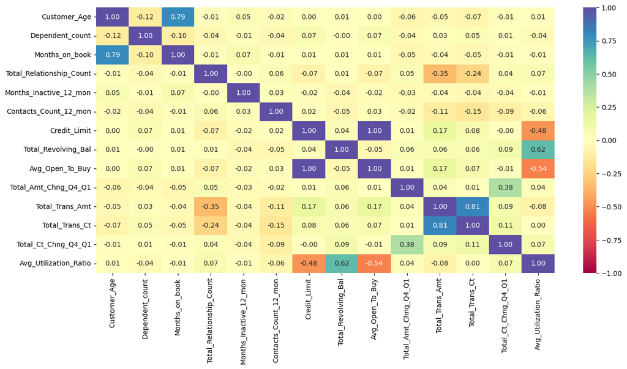

```python
# Correlation plot
plt.figure(figsize=(15, 7))
sns.heatmap(df[numerical_columns].corr(), annot=True, vmin=-1, vmax=1, fmt=".2f", cmap="Spectral")
plt.show()
```

- From the above heat map we could find there are positive and negative correlations among certain variables. There is positive correlation among features like age vs month on book, credit limit vs Avg open to buy, total transaction count vs total transaction amount, revolving balance vs avg utilization ratio.
- negative correlation for avg open to buy vs avg utilization ratio, credit limit vs avg utilization ratio, total transaction amount vs total relationship count.

## Data Pre-processing

### Data preparation for Modeling

```python
# Split the dataset into 3 sets train, test, validation sets
X = df.drop('Attrition_Flag', axis=1)
y = df['Attrition_Flag'].apply(lambda x: 1 if x == "Attrited Customer" else 0)
```

```python
# Lets first split to temp and test and then split the temp to train and validation sets
X_temp, X_test, y_temp, y_test = train_test_split(X, y, test_size=0.2, random_state=1, stratify=y)
X_train, X_val, y_train, y_val = train_test_split(X_temp, y_temp, test_size=0.25, random_state=1, stratify=y_temp)
```

```python
# Lets print the shape
print("Shape of X_train: ", X_train.shape)
print("Shape of y_train: ", y_train.shape)
```

```
Shape of X_train:  (6075, 19)
Shape of y_train:  (6075,)
```

## Missing value imputation

- The columns that had missing values are Education_Level and Marital_Status and they are replaced with Unknown category.

### Creating Dummy variables

```python
X_train = pd.get_dummies(X_train, drop_first=True)
X_val = pd.get_dummies(X_val, drop_first=True)
X_test = pd.get_dummies(X_test, drop_first=True)
```

```python
X_train.shape, X_val.shape, X_test.shape
```

```
((6075, 32), (2026, 32), (2026, 32))
```

```python
X_train.head()
```

|  | Customer_Age | Dependent_count | Months_on_book | Total_Relationship_Count | Months_Inactive_12_mon | Contacts_Count_12_mon | Credit_Limit | Total_Revolving_Bal | Avg_Open_To_Buy | Total_Amt_Chng_Q4_Q1 | ... | Marital_Status_Single | Marital_Status_Unknown | Income_Category_$40K - $60K | Income_Category_$60K - $80K | Income_Category_$80K - $120K | Income_Category_Less than $40K | Income_Category_abc | Card_Category_Gold | Card_Category_Platinum | Card_Category_Silver |
| --- | --- | --- | --- | --- | --- | --- | --- | --- | --- | --- | --- | --- | --- | --- | --- | --- | --- | --- | --- | --- | --- |
| 800 | 40 | 2 | 21 | 6 | 4 | 3 | 20056.000000 | 1602 | 18454.000000 | 0.466000 | ... | True | False | False | False | False | False | False | False | False | False |
| 498 | 44 | 1 | 34 | 6 | 2 | 0 | 2885.000000 | 1895 | 990.000000 | 0.387000 | ... | False | False | False | False | False | False | True | False | False | False |
| 4356 | 48 | 4 | 36 | 5 | 1 | 2 | 6798.000000 | 2517 | 4281.000000 | 0.873000 | ... | False | False | False | False | True | False | False | False | False | False |
| 407 | 41 | 2 | 36 | 6 | 2 | 0 | 27000.000000 | 0 | 27000.000000 | 0.610000 | ... | False | True | False | True | False | False | False | False | False | True |
| 8728 | 46 | 4 | 36 | 2 | 2 | 3 | 15034.000000 | 1356 | 13678.000000 | 0.754000 | ... | False | False | True | False | False | False | False | False | False | True |

5 rows × 32 columns

```python
X_train.info()
```

```
<class 'pandas.core.frame.DataFrame'>
Index: 6075 entries, 800 to 4035
Data columns (total 32 columns):
 #   Column                          Non-Null Count  Dtype
---  ------                          --------------  -----
 0   Customer_Age                    6075 non-null   int64
 1   Dependent_count                 6075 non-null   int64
 2   Months_on_book                  6075 non-null   int64
 3   Total_Relationship_Count        6075 non-null   int64
 4   Months_Inactive_12_mon          6075 non-null   int64
 5   Contacts_Count_12_mon           6075 non-null   int64
 6   Credit_Limit                    6075 non-null   float64
 7   Total_Revolving_Bal             6075 non-null   int64
 8   Avg_Open_To_Buy                 6075 non-null   float64
 9   Total_Amt_Chng_Q4_Q1            6075 non-null   float64
```

[output cut: 24 more lines]

## Model Building

### Model evaluation criterion

The nature of predictions made by the classification model will translate as follows:

- True positives (TP) are the values model predicts customers will attrite.
- False negatives (FN) are the values that the model predicts customers will stay with the bank but in real world they attrite.
- Our goal is to find all the true positives and reduce false negatives where the model correctly predicts the customer attrite or not. So overall the recall score needs to be improved.
- Recall is the number of TP model predicts to the actual postives ( TP + FN). TP / (TP + FN)

**Which metric to optimize?**

- We would want Recall to be maximized as greater the Recall, the higher the chances of minimizing false negatives.
- We want to minimize false negatives because if a model predicts that the customer will not attrite it incurs loss for the bank.

**Let's define a function to output different metrics (including recall) on the train and test set and a function to show confusion matrix so that we do not have to use the same code repetitively while evaluating models.**

```python
# defining a function to compute different metrics to check performance of a classification model built using sklearn
def model_performance_classification_sklearn(model, predictors, target):
    """
    Function to compute different metrics to check classification model performance

    model: classifier
    predictors: independent variables
    target: dependent variable
    """

    # predicting using the independent variables
    pred = model.predict(predictors)

    acc = accuracy_score(target, pred)  # to compute Accuracy
    recall = recall_score(target, pred)  # to compute Recall
    precision = precision_score(target, pred)  # to compute Precision
    f1 = f1_score(target, pred)  # to compute F1-score

    # creating a dataframe of metrics
    df_perf = pd.DataFrame(
        {
            "Accuracy": acc,
            "Recall": recall,
            "Precision": precision,
            "F1": f1

        },
        index=[0],
    )

    return df_perf
```

```python
def confusion_matrix_sklearn(model, predictors, target):
    """
    To plot the confusion_matrix with percentages

    model: classifier
    predictors: independent variables
    target: dependent variable
    """
    y_pred = model.predict(predictors)
    cm = confusion_matrix(target, y_pred)
    labels = np.asarray(
        [
            ["{0:0.0f}".format(item) + "\n{0:.2%}".format(item / cm.flatten().sum())]
            for item in cm.flatten()
        ]
    ).reshape(2, 2)
    plt.figure(figsize=(6, 4))
    sns.heatmap(cm, annot=labels, fmt="")
    plt.ylabel("True label")
    plt.xlabel("Predicted label")
```

### Model Building with original data

Sample code for model building with original data

```python
models = []  # Empty list to store all the models

# Appending models into the list
models.append(("Decision tree", DecisionTreeClassifier(random_state=1)))
models.append(("Bagging", BaggingClassifier(random_state=1)))
models.append(("Random forest", RandomForestClassifier(random_state=1)))
models.append(("AdaBoost", AdaBoostClassifier(random_state=1)))
models.append(("GradientBoost", GradientBoostingClassifier(random_state=1)))
models.append(("XGBoost", XGBClassifier(random_state=1)))

print("\n" "Training Performance:" "\n")
for name, model in models:
    model.fit(X_train, y_train)
    scores = recall_score(y_train, model.predict(X_train))
    print("{}: {}".format(name, scores))

print("\n" "Validation Performance:" "\n")

for name, model in models:
    model.fit(X_train, y_train)
    scores_val = recall_score(y_val, model.predict(X_val))
    print("{}: {}".format(name, scores_val))
```

```
Training Performance:

Decision tree: 1.0
Bagging: 0.9846311475409836
Random forest: 1.0
AdaBoost: 0.8381147540983607
GradientBoost: 0.8780737704918032
XGBoost: 1.0

Validation Performance:

Decision tree: 0.7975460122699386
Bagging: 0.7975460122699386
Random forest: 0.7944785276073619
AdaBoost: 0.8588957055214724
GradientBoost: 0.8588957055214724
XGBoost: 0.8895705521472392
```

### The Boosting models perform well with the train and validation sets. Out of all XGBoost has the highest recall score of 89% on validation dataset.

### Model Building with Oversampled data

```python
# Synthetic Minority Over Sampling Technique
print("Before Oversampling, counts of label 'Yes': {}".format(sum(y_train == 1)))
print("Before Oversampling, counts of label 'No': {} \n".format(sum(y_train == 0)))

sm = SMOTE(sampling_strategy=1, k_neighbors=5, random_state=1)
X_train_over, y_train_over = sm.fit_resample(X_train, y_train)

print("After Oversampling, counts of label 'Yes': {}".format(sum(y_train_over == 1)))
print("After Oversampling, counts of label 'No': {}".format(sum(y_train_over == 0)))
```

```
Before Oversampling, counts of label 'Yes': 976
Before Oversampling, counts of label 'No': 5099

After Oversampling, counts of label 'Yes': 5099
After Oversampling, counts of label 'No': 5099
```

```python
print("After Oversampling, the shape of train_X: {}".format(X_train_over.shape))
print("After Oversampling, the shape of train_y: {} \n".format(y_train_over.shape))
```

```
After Oversampling, the shape of train_X: (10198, 32)
After Oversampling, the shape of train_y: (10198,)
```

```python
print( "\n Training Performance after oversampling \n ")
models = []
models.append(("Decision tree", DecisionTreeClassifier(random_state=1)))
models.append(("Bagging", BaggingClassifier(random_state=1)))
models.append(("Random forest", RandomForestClassifier(random_state=1)))
models.append(("AdaBoost", AdaBoostClassifier(random_state=1)))
models.append(("GradientBoost", GradientBoostingClassifier(random_state=1)))
models.append(("XGBoost", XGBClassifier(random_state=1)))

for name, model in models:
    model.fit(X_train_over, y_train_over)
    train_score = recall_score(y_train_over, model.predict(X_train_over))
    validation_score = recall_score(y_val, model.predict(X_val))
    print("{} Training Score: {:.4f}  Validation Score: {:.4f}  ".format(name, train_score, validation_score))
```

```
 Training Performance after oversampling

Decision tree Training Score: 1.0000  Validation Score: 0.8497
Bagging Training Score: 0.9975  Validation Score: 0.8742
Random forest Training Score: 1.0000  Validation Score: 0.8712
AdaBoost Training Score: 0.9614  Validation Score: 0.8865
GradientBoost Training Score: 0.9765  Validation Score: 0.9141
XGBoost Training Score: 1.0000  Validation Score: 0.9202
```

### Model Building with Undersampled data

```python
print("Before Undersampling, counts of label 'Yes': {}".format(sum(y_train == 1)))
print("Before Undersampling, counts of label 'No': {} \n".format(sum(y_train == 0)))

# Random undersampler for under sampling the data
rus = RandomUnderSampler(random_state=1, sampling_strategy=1)
X_train_un, y_train_un = rus.fit_resample(X_train, y_train)

print("After Undersampling, counts of label 'Yes': {}".format(sum(y_train_un == 1)))
print("After Undersampling, counts of label 'No': {}".format(sum(y_train_un == 0)))

print("After Undersampling, the shape of train_X: {}".format(X_train_un.shape))
print("After Undersampling, the shape of train_y: {} \n".format(y_train_un.shape))
```

```
Before Undersampling, counts of label 'Yes': 976
Before Undersampling, counts of label 'No': 5099

After Undersampling, counts of label 'Yes': 976
After Undersampling, counts of label 'No': 976
After Undersampling, the shape of train_X: (1952, 32)
After Undersampling, the shape of train_y: (1952,)
```

```python
models = []
models.append(("Decision tree", DecisionTreeClassifier(random_state=1)))
models.append(("Bagging", BaggingClassifier(random_state=1)))
models.append(("Random forest", RandomForestClassifier(random_state=1)))
models.append(("AdaBoost", AdaBoostClassifier(random_state=1)))
models.append(("GradientBoost", GradientBoostingClassifier(random_state=1)))
models.append(("XGBoost", XGBClassifier(random_state=1)))

for name, model in models:
    model.fit(X_train_un, y_train_un)
    train_score = recall_score(y_train_un, model.predict(X_train_un))
    validation_score = recall_score(y_val, model.predict(X_val))
    print("{} Training Score: {:.4f}  Validation Score: {:.4f}  ".format(name, train_score, validation_score))
```

```
Decision tree Training Score: 1.0000  Validation Score: 0.8926
Bagging Training Score: 0.9918  Validation Score: 0.9264
Random forest Training Score: 1.0000  Validation Score: 0.9294
AdaBoost Training Score: 0.9529  Validation Score: 0.9601
GradientBoost Training Score: 0.9826  Validation Score: 0.9601
XGBoost Training Score: 1.0000  Validation Score: 0.9663
```

### We choose Adaboost, GradientBoost and XGBoost models for the hyper parameter tuning

**Note**

1. Sample parameter grids have been provided to do necessary hyperparameter tuning. These sample grids are expected to provide a balance between model performance improvement and execution time. One can extend/reduce the parameter grid based on execution time and system configuration.
   - Please note that if the parameter grid is extended to improve the model performance further, the execution time will increase
- For Gradient Boosting:

```
param_grid = {
    "init": [AdaBoostClassifier(random_state=1),DecisionTreeClassifier(random_state=1)],
    "n_estimators": np.arange(50,110,25),
    "learning_rate": [0.01,0.1,0.05],
    "subsample":[0.7,0.9],
    "max_features":[0.5,0.7,1],
}
```

- For Adaboost:

```
param_grid = {
    "n_estimators": np.arange(50,110,25),
    "learning_rate": [0.01,0.1,0.05],
    "base_estimator": [
        DecisionTreeClassifier(max_depth=2, random_state=1),
        DecisionTreeClassifier(max_depth=3, random_state=1),
    ],
}
```

- For Bagging Classifier:

```
param_grid = {
    'max_samples': [0.8,0.9,1],
    'max_features': [0.7,0.8,0.9],
    'n_estimators' : [30,50,70],
}
```

- For Random Forest:

```
param_grid = {
    "n_estimators": [50,110,25],
    "min_samples_leaf": np.arange(1, 4),
    "max_features": [np.arange(0.3, 0.6, 0.1),'sqrt'],
    "max_samples": np.arange(0.4, 0.7, 0.1)
}
```

- For Decision Trees:

```
param_grid = {
    'max_depth': np.arange(2,6),
    'min_samples_leaf': [1, 4, 7],
    'max_leaf_nodes' : [10, 15],
    'min_impurity_decrease': [0.0001,0.001]
}
```

- For XGBoost (optional):

```
param_grid={'n_estimators':np.arange(50,110,25),
            'scale_pos_weight':[1,2,5],
            'learning_rate':[0.01,0.1,0.05],
            'gamma':[1,3],
            'subsample':[0.7,0.9]
}
```

### HyperparamaterTuning AdaBoostClassifier

```python
# Tuning Adaboost classifier with undersamppled data
%%time

# defining model
Model = AdaBoostClassifier(random_state=1)

# Parameter grid to pass in RandomSearchCV
param_grid = {
    "n_estimators": np.arange(50,110,25),
    "learning_rate": [0.01,0.1,0.05],
    "base_estimator": [
        DecisionTreeClassifier(max_depth=2, random_state=1),
        DecisionTreeClassifier(max_depth=3, random_state=1),
    ],
}

# Type of scoring used to compare parameter combinations
scorer = metrics.make_scorer(metrics.recall_score)

#Calling RandomizedSearchCV
randomized_cv = RandomizedSearchCV(estimator=Model, param_distributions=param_grid, n_jobs = -1, n_iter=50, scoring=scorer, cv=5, random_state=1)

#Fitting parameters in RandomizedSearchCV
randomized_cv.fit(X_train_un, y_train_un)

print("Best parameters are {} with CV score={}:" .format(randomized_cv.best_params_,randomized_cv.best_score_))
```

```
Best parameters are {'n_estimators': 100, 'learning_rate': 0.05, 'base_estimator': DecisionTreeClassifier(max_depth=3, random_state=1)} with CV score=0.9477655677655678:
CPU times: user 1.92 s, sys: 175 ms, total: 2.1 s
Wall time: 54.7 s
```

```python
tuned_adb = randomized_cv.best_estimator_
tuned_adb.fit(X_train_un, y_train_un)
```

```
AdaBoostClassifier(base_estimator=DecisionTreeClassifier(max_depth=3,
                                                         random_state=1),
                   learning_rate=0.05, n_estimators=100, random_state=1)
```

```python
# Checking model's performance on training set
adb_train = model_performance_classification_sklearn(tuned_adb, X_train_un, y_train_un)
adb_train
```

|  | Accuracy | Recall | Precision | F1 |
| --- | --- | --- | --- | --- |
| 0 | 0.972336 | 0.977459 | 0.967546 | 0.972477 |

```python
# Checking model's performance on validation set
adb_val = model_performance_classification_sklearn(tuned_adb, X_val, y_val)
adb_val
```

|  | Accuracy | Recall | Precision | F1 |
| --- | --- | --- | --- | --- |
| 0 | 0.936821 | 0.966258 | 0.729167 | 0.831135 |

### HyperparameterTuning GBM with UnderSampled data

```python
Model = GradientBoostingClassifier(random_state=1)
param_grid = {
    "init": [AdaBoostClassifier(random_state=1),DecisionTreeClassifier(random_state=1)],
    "n_estimators": np.arange(50,110,25),
    "learning_rate": [0.01,0.1,0.05],
    "subsample":[0.7,0.9],
    "max_features":[0.5,0.7,1],
}
# Type of scoring used to compare parameter combinations
scorer = metrics.make_scorer(metrics.recall_score)

#Calling RandomizedSearchCV
randomized_cv = RandomizedSearchCV(estimator=Model, param_distributions=param_grid, n_jobs = -1, n_iter=50, scoring=scorer, cv=5, random_state=1)

#Fitting parameters in RandomizedSearchCV
randomized_cv.fit(X_train_un, y_train_un)

print("Best parameters are {} with CV score={}:" .format(randomized_cv.best_params_,randomized_cv.best_score_))
```

```
Best parameters are {'subsample': 0.9, 'n_estimators': 100, 'max_features': 0.5, 'learning_rate': 0.1, 'init': AdaBoostClassifier(random_state=1)} with CV score=0.9518419675562534:
```

```python
tuned_gbm = randomized_cv.best_estimator_
tuned_gbm.fit(X_train_un, y_train_un)
```

```
GradientBoostingClassifier(init=AdaBoostClassifier(random_state=1),
                           max_features=0.5, random_state=1, subsample=0.9)
```

```python
#Checking model's performance on Training set
gbm_train = model_performance_classification_sklearn(tuned_gbm, X_train_un, y_train_un)
gbm_train
```

|  | Accuracy | Recall | Precision | F1 |
| --- | --- | --- | --- | --- |
| 0 | 0.976947 | 0.981557 | 0.972589 | 0.977053 |

```python
#Checking model's performance on Validation set
gbm_val = model_performance_classification_sklearn(tuned_gbm, X_val, y_val)
gbm_val
```

|  | Accuracy | Recall | Precision | F1 |
| --- | --- | --- | --- | --- |
| 0 | 0.941757 | 0.960123 | 0.748804 | 0.841398 |

### HyperParameterTuning GBM with Oversampled data

```python
Model = GradientBoostingClassifier(random_state=1)
param_grid = {
    "init": [AdaBoostClassifier(random_state=1),DecisionTreeClassifier(random_state=1)],
    "n_estimators": np.arange(50,110,25),
    "learning_rate": [0.01,0.1,0.05],
    "subsample":[0.7,0.9],
    "max_features":[0.5,0.7,1],
}
# Type of scoring used to compare parameter combinations
scorer = metrics.make_scorer(metrics.recall_score)

#Calling RandomizedSearchCV
randomized_cv = RandomizedSearchCV(estimator=Model, param_distributions=param_grid, n_jobs = -1, n_iter=50, scoring=scorer, cv=5, random_state=1)

#Fitting parameters in RandomizedSearchCV
randomized_cv.fit(X_train_over, y_train_over)

print("Best parameters are {} with CV score={}:" .format(randomized_cv.best_params_,randomized_cv.best_score_))
```

```
Best parameters are {'subsample': 0.7, 'n_estimators': 75, 'max_features': 0.7, 'learning_rate': 0.05, 'init': AdaBoostClassifier(random_state=1)} with CV score=0.9509753891743156:
```

```python
tuned_gbm_over = randomized_cv.best_estimator_
tuned_gbm_over.fit(X_train_over, y_train_over)
```

```
GradientBoostingClassifier(init=AdaBoostClassifier(random_state=1),
                           learning_rate=0.05, max_features=0.7,
                           n_estimators=75, random_state=1, subsample=0.7)
```

```python
#Checking the model performance on the train dataset
gbm_train_over = model_performance_classification_sklearn(tuned_gbm_over, X_train_over, y_train_over)
gbm_train_over
```

|  | Accuracy | Recall | Precision | F1 |
| --- | --- | --- | --- | --- |
| 0 | 0.954207 | 0.963522 | 0.945899 | 0.954629 |

```python
#Checking the model performance on the validation dataset
gbm_val_over = model_performance_classification_sklearn(tuned_gbm_over, X_val, y_val)
gbm_val_over
```

|  | Accuracy | Recall | Precision | F1 |
| --- | --- | --- | --- | --- |
| 0 | 0.937315 | 0.907975 | 0.753181 | 0.823366 |

### HyperParameterTuning XGBoost Classifier with Undersampled data

```python
# hyperparameter tuning the XGBoost Clssifier with undersampled data
Model = XGBClassifier(random_state=1)
param_grid={'n_estimators':np.arange(50,110,25),
            'scale_pos_weight':[1,2,5],
            'learning_rate':[0.01,0.1,0.05],
            'gamma':[1,3],
            'subsample':[0.7,0.9]
}
#Type of scoring used to compare parameter combinations
scorer = metrics.make_scorer(metrics.recall_score)

#Calling RandomizedSearchCV
randomized_cv = RandomizedSearchCV(estimator=Model, param_distributions=param_grid, n_jobs = -1, n_iter=50, scoring=scorer, cv=5, random_state=1)

#Fitting parameters in RandomizedSearchCV
randomized_cv.fit(X_train_un, y_train_un)

print("Best parameters are {} with CV score={}:" .format(randomized_cv.best_params_,randomized_cv.best_score_))
```

```
Best parameters are {'subsample': 0.7, 'scale_pos_weight': 5, 'n_estimators': 50, 'learning_rate': 0.01, 'gamma': 3} with CV score=0.996938775510204:
```

```python
tuned_xgb_under = randomized_cv.best_estimator_
tuned_xgb_under.fit(X_train_un, y_train_un)
```

```
XGBClassifier(base_score=None, booster=None, callbacks=None,
              colsample_bylevel=None, colsample_bynode=None,
              colsample_bytree=None, device=None, early_stopping_rounds=None,
              enable_categorical=False, eval_metric=None, feature_types=None,
              gamma=3, grow_policy=None, importance_type=None,
              interaction_constraints=None, learning_rate=0.01, max_bin=None,
              max_cat_threshold=None, max_cat_to_onehot=None,
              max_delta_step=None, max_depth=None, max_leaves=None,
              min_child_weight=None, missing=nan, monotone_constraints=None,
              multi_strategy=None, n_estimators=50, n_jobs=None,
              num_parallel_tree=None, random_state=1, ...)
```

```python
# Checking the perforamce metrics on train dataset
xgb_train = model_performance_classification_sklearn(tuned_xgb_under, X_train_un, y_train_un)
xgb_train
```

|  | Accuracy | Recall | Precision | F1 |
| --- | --- | --- | --- | --- |
| 0 | 0.763320 | 1.000000 | 0.678720 | 0.808616 |

```python
#Checking the performance metrics on validation dataset
xgb_val = model_performance_classification_sklearn(tuned_xgb_under, X_val, y_val)
xgb_val
```

|  | Accuracy | Recall | Precision | F1 |
| --- | --- | --- | --- | --- |
| 0 | 0.582922 | 1.000000 | 0.278395 | 0.435538 |

### HyperparameterTuning the XGBoost CLassifier with oversampled data

```python
Model = XGBClassifier(random_state = 1)
param_grid = {'n_estimators':np.arange(50,110,25),
            'scale_pos_weight':[1,2,5],
            'learning_rate':[0.01,0.1,0.05],
            'gamma':[1,3],
            'subsample':[0.7,0.9]
}
#Type of scoring used to compare parameter combinations
scorer = metrics.make_scorer(metrics.recall_score)

#Calling RandomizedSearchCV
randomized_cv = RandomizedSearchCV(estimator=Model, param_distributions=param_grid, n_jobs = -1, n_iter=50, scoring=scorer, cv=5, random_state=1)

#Fitting parameters in RandomizedSearchCV
randomized_cv.fit(X_train_over, y_train_over)

print("Best parameters are {} with CV score={}:" .format(randomized_cv.best_params_,randomized_cv.best_score_))
```

```
Best parameters are {'subsample': 0.7, 'scale_pos_weight': 5, 'n_estimators': 50, 'learning_rate': 0.01, 'gamma': 3} with CV score=0.9990196078431373:
```

```python
tuned_xgb_over = randomized_cv.best_estimator_
tuned_xgb_over.fit(X_train_over, y_train_over)
```

```
XGBClassifier(base_score=None, booster=None, callbacks=None,
              colsample_bylevel=None, colsample_bynode=None,
              colsample_bytree=None, device=None, early_stopping_rounds=None,
              enable_categorical=False, eval_metric=None, feature_types=None,
              gamma=3, grow_policy=None, importance_type=None,
              interaction_constraints=None, learning_rate=0.01, max_bin=None,
              max_cat_threshold=None, max_cat_to_onehot=None,
              max_delta_step=None, max_depth=None, max_leaves=None,
              min_child_weight=None, missing=nan, monotone_constraints=None,
              multi_strategy=None, n_estimators=50, n_jobs=None,
              num_parallel_tree=None, random_state=1, ...)
```

```python
#Checking the model performance on the training dataset
xgb_train_over = model_performance_classification_sklearn(tuned_xgb_over, X_train_over, y_train_over)
xgb_train_over
```

|  | Accuracy | Recall | Precision | F1 |
| --- | --- | --- | --- | --- |
| 0 | 0.792606 | 1.000000 | 0.706820 | 0.828230 |

```python
#Checking the model performance on the validation dataset
xgb_val_over = model_performance_classification_sklearn(tuned_xgb_over, X_val, y_val)
xgb_val_over
```

|  | Accuracy | Recall | Precision | F1 |
| --- | --- | --- | --- | --- |
| 0 | 0.652517 | 1.000000 | 0.316505 | 0.480826 |

## Model Comparison and Final Model Selection

```python
models_train_comp_df = pd.concat(
    [
        gbm_train.T,
        gbm_train_over.T,
        adb_train.T,
        xgb_train.T,
        xgb_train_over.T,
    ],
    axis=1,
)
models_train_comp_df.columns = [
    "Gradient boosting trained with Undersampled data",
    "Gradient boosting trained with Oversampled data",
    "AdaBoost trained with Undersampled data",
    "XGBoost trained with Undersampled data",
    "XGBoost trained with Oversampled data"
]
print("Training performance comparison:")
models_train_comp_df
```

```
Training performance comparison:
```

|  | Gradient boosting trained with Undersampled data | Gradient boosting trained with Oversampled data | AdaBoost trained with Undersampled data | XGBoost trained with Undersampled data | XGBoost trained with Oversampled data |
| --- | --- | --- | --- | --- | --- |
| Accuracy | 0.976947 | 0.954207 | 0.972336 | 0.763320 | 0.792606 |
| Recall | 0.981557 | 0.963522 | 0.977459 | 1.000000 | 1.000000 |
| Precision | 0.972589 | 0.945899 | 0.967546 | 0.678720 | 0.706820 |
| F1 | 0.977053 | 0.954629 | 0.972477 | 0.808616 | 0.828230 |

```python
models_validation_comp_df = pd.concat(
    [
        gbm_val.T,
        gbm_val_over.T,
        adb_val.T,
        xgb_val.T,
        xgb_val_over.T,
    ],
    axis=1,
)
models_validation_comp_df.columns = [
    "Gradient boosting trained with Undersampled data",
    "Gradient boosting trained with Oversampled data",
    "AdaBoost trained with Undersampled data",
    "XGBoost trained with Undersampled data",
    "XGBoost trained with Oversampled data"
]
print("Validation performance comparison:")
models_validation_comp_df
```

```
Validation performance comparison:
```

|  | Gradient boosting trained with Undersampled data | Gradient boosting trained with Oversampled data | AdaBoost trained with Undersampled data | XGBoost trained with Undersampled data | XGBoost trained with Oversampled data |
| --- | --- | --- | --- | --- | --- |
| Accuracy | 0.941757 | 0.937315 | 0.936821 | 0.582922 | 0.652517 |
| Recall | 0.960123 | 0.907975 | 0.966258 | 1.000000 | 1.000000 |
| Precision | 0.748804 | 0.753181 | 0.729167 | 0.278395 | 0.316505 |
| F1 | 0.841398 | 0.823366 | 0.831135 | 0.435538 | 0.480826 |

### Our final model is GradientBoostClassifierModel trained with Undersampled Data

### Test set final performance

```python
gbm_test = model_performance_classification_sklearn(tuned_gbm, X_test, y_test)
gbm_test
```

|  | Accuracy | Recall | Precision | F1 |
| --- | --- | --- | --- | --- |
| 0 | 0.936821 | 0.963077 | 0.729604 | 0.830239 |

- The GradientBoost Classifier trained with Undersampled data is our final model
- This model gives the Recall score of 96% for test, validation sets and 98% for train dataset.
- This model performance is the best for our problem and generalizes well on unseen data.

### Feature Importance

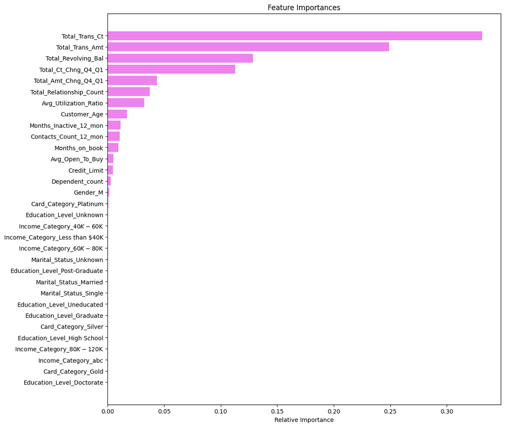

```python
feature_names = X_train.columns
importances = tuned_gbm.feature_importances_
indices = np.argsort(importances)

plt.figure(figsize=(12, 12))
plt.title("Feature Importances")
plt.barh(range(len(indices)), importances[indices], color="violet", align="center")
plt.yticks(range(len(indices)), [feature_names[i] for i in indices])
plt.xlabel("Relative Importance")
plt.show()
```

# Business Insights and Conclusions

- Based on our analysis, the total transactions, amount of transactions, revolving balance are the main factors for the customers to renounce using credit card services.
- The bank might be charging more interests for their customers when the revolving balnce is high which makes them attrite.
- When you look at the EDA , the lower income people(Less than $40K) are the more to attrite which indicates that they couldnt afford paying their balance with huge interests with their very low income.
- If the bank looks at their demographics information ( age, income, salary) etc and dont charge penalties or interest they more likely help their clients not to churn.
- This ends our conclusion on credit card users churn prediction.